# Covid-19 state in Romania

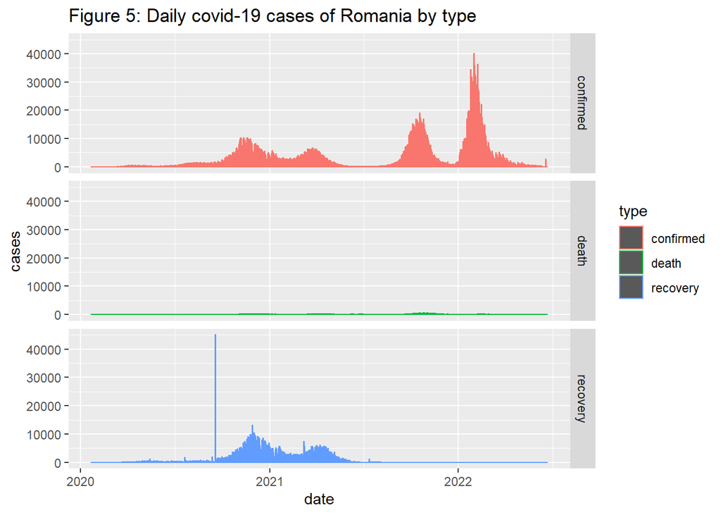

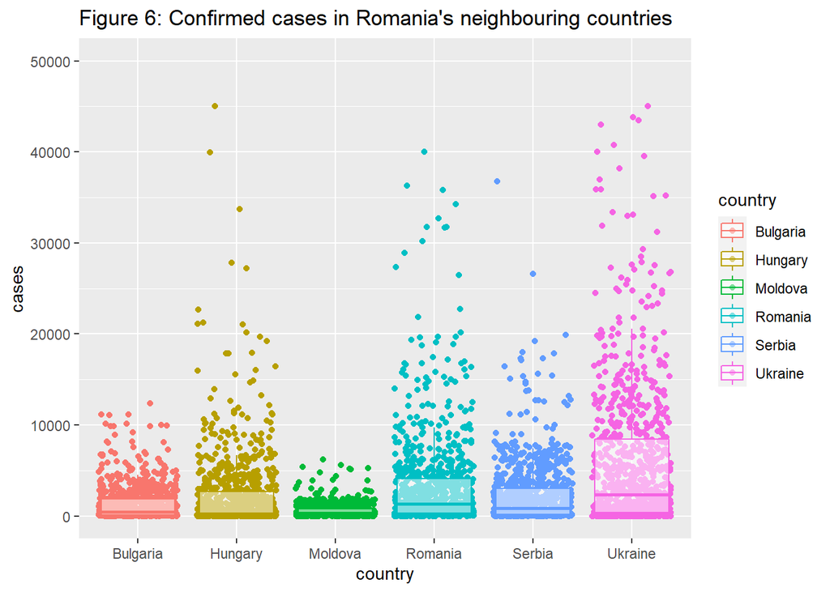

Among neighbouring countries Ukraine shows the highest average reported confirm covid-19 cases per day. And Romania shows the second highest value of that. Highest reported confirm covid-19 cases per day was reported from Hungary and Ukraine. Meanwhile Moldova shows the lowest average reported confirm covid-19 cases per day.

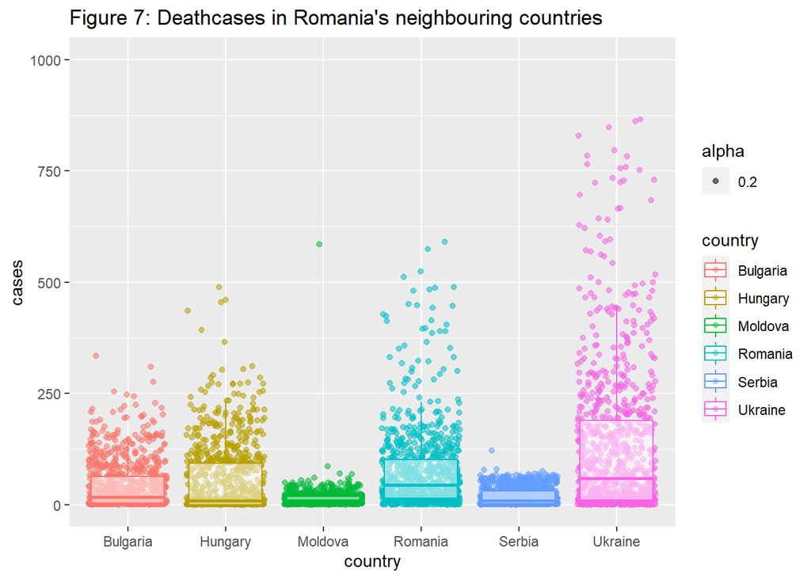

Highest deathcount per day was recorded in Ukraine Romania’s deathcount was comparatively lower than that. But the mean recorded deathcount per day fo both Ukraine and Romania is approximately equal.

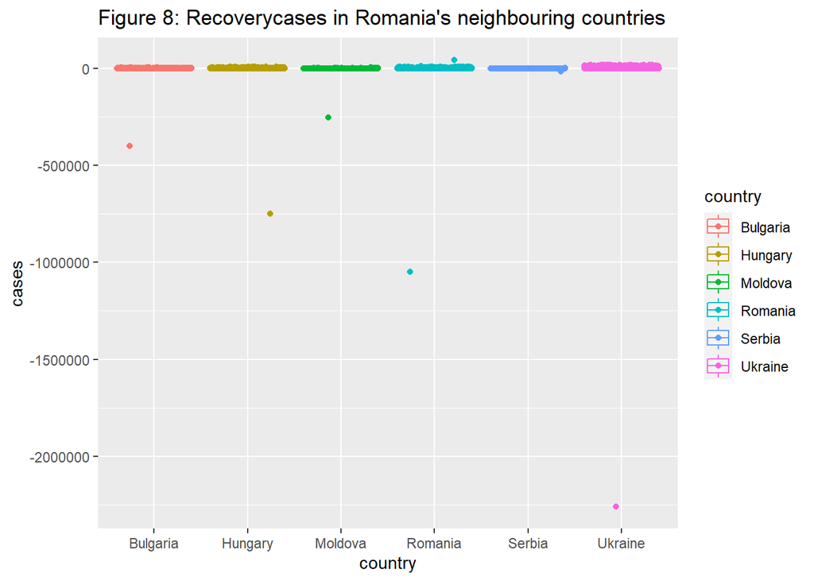

This figure shows there were few number of minus values recorded in each country.

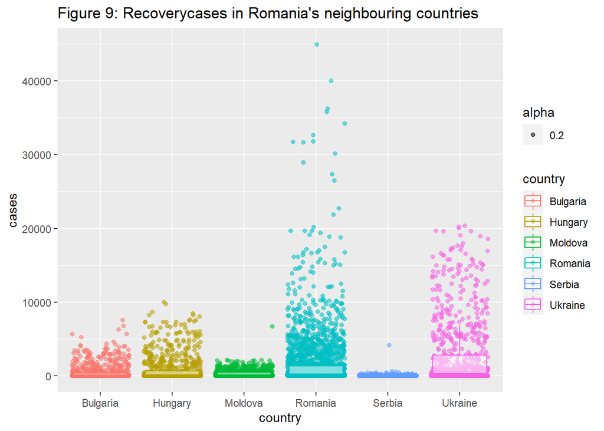

Acoding to this figure Romania shows the highest recorded recovery counts than the other neighbouring countries. But Ukraine shows higest recorded mean recovery count per day.

### Let us consider the COVID-19 recovery cases in Ukrain and Romania

[figure not shown]

If we consider the recorded recovery data broadly we can see that Romaina had done good job recovering from the COVID-19 than the Ukrain after all.

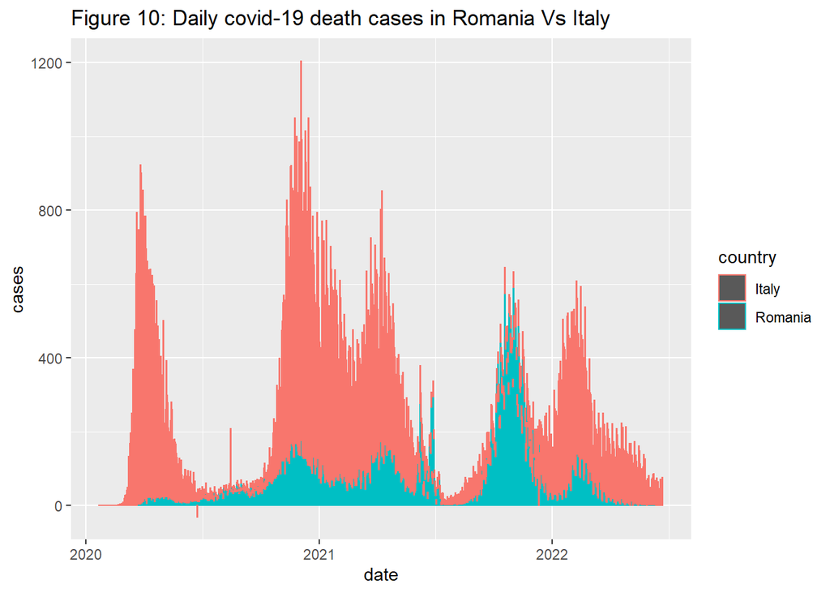

## References

Wikipedia - [https://en.wikipedia.org/wiki/Romania#:~:text=Romania%20is%20the%20twelfth%2Dlargest,Romania.]

https://www.frontiersin.org/articles/10.3389/fpubh.2021.813941/full

https://borgenproject.org/healthcare-in-romania/